# R Notebook

# DEseq2 notebook

DEseq2 Analysis based on the tutorial provided by: https://bioconductor.org/packages/release/workflows/vignettes/rnaseqGene/inst/doc/rnaseqGene.html

Data input: RNA-seq high throughput **un-normalised** count matrix. rows = genes and columns = experiments, thus counts[i][j] = counts[gene_i][experiment_j].

The tutorial above describes getting from reads into count matrices however, I’m just going to start from the summarized data in a count matrix.

## KIRC

```r
# If you need to install it:
#BiocManager::install('DESeq2')
library("DESeq2")
library("stringr")
library("tidyverse")
# Here we'll set the project directory so that from now on we'll always have our files w.r.t. this dir.
projectDir <- 'data/'
fhlow <- 'outlier'
fhcontrol <- 'high'
cancer <- 'kirc'

" To test between different ones just change it here e.g. to test kirp or kirc"
```

```
[1] " To test between different ones just change it here e.g. to test kirp or kirc"
```

```r
filename <- paste(projectDir, cancer, '_tumour_', fhcontrol, '_', fhlow, '_df.csv', sep='')

# Read in the count matrix
counts <- read.csv(filename, header = TRUE, sep = ",")

# We want to rename the rows and make sure they are labeled by the gene_id (note you'll have to select whatever your ID column name is here)
" Set <gene_id> to be the column with the gene IDs "
```

```
[1] " Set <gene_id> to be the column with the gene IDs "
```

```r
rownames(counts) <- counts$id
genes <- counts$id
gene_names <- counts$external_gene_name
# Note if we're testing for Fh-deficient differences between tumours, we don't want to include the healthy samples
# So we filter out by selecting only the columns that contain Tumour

# Let's make sure our count data is in matrix format and is only the numeric columns i.e. everything but the genes
counts <- counts[,3:ncol(counts)]

# Here we get the names of the columns, for my stuff I always have all the info in one string as I find it makes it easier
# this means each of the "groups" are separated by a "_" this may be different for you
sampleNames <- colnames(counts) # Sample names



# For DEseq2 we need to turn this into a dataframe
sampleDF = read.csv(paste0('data/', cancer, '_', fhcontrol, '_', fhlow, '_sample_df.csv'), header = TRUE, sep = ",")

condition_id <- as.factor(sampleDF$condition)
# Make sure we don't include the ID in our columns
countMatrix <- as.matrix(counts)

# We now set the row names to be the gene IDs
rownames(countMatrix) <- gene_names
```

## Starting the DEseq2 Analysis

Now we can start to run the DEseq2 analysis or the EdgeR, both use the data in the above format.

First we want to set the design for the experiment, from the above webpage:

> If the research aim is to determine for which genes the effect of treatment is different across groups, then interaction terms can be included and tested using a design such as ~ group + treatment + group:treatment.

For us since we’re looking at TCGA maybe we want to look at our treatment as sampleTypes e.g. “Tumour” vs “PrimaryTissueNormal” and our groups as gender e.g: “female”, “male”.

```r
# Create a DEseq2 dataset from the counts using our count matrix note we need to set our colum data as factors
gender = gender=sampleDF$Sex
sample_df = data.frame(condition_id=condition_id, label=sampleDF$Label, fhStatus=sampleDF$FH_status, gender=sampleDF$Sex)
ddsMat <- DESeqDataSetFromMatrix(countData = countMatrix,
                                 colData = sample_df,
                                 design = ~condition_id)
```

```
960 duplicate rownames were renamed by adding numbers
```

### Prefiltering data

Note the more samples that are kept, the more statistical tests you need to perform, thus they will need to pass a higher FDR. It may be important here to filter many of the not so good genes if you wish to pick up on smaller changes such as transcription factors, or more variable genes such as cell cycle genes.

```r
"
Here is the example of something you might do if you have only very few samples:

keep <- rowSums(counts(dds)) > 1
dds <- dds[keep,]
"
```

```
[1] "\nHere is the example of something you might do if you have only very few samples:\n\nkeep <- rowSums(counts(dds)) > 1\ndds <- dds[keep,]\n"
```

```r
# Create a DEseq2 dataset from the counts using our
numSamplesMeetingCriteria <- 6
numCountsInGene <- 10
keep <- rowSums(counts(ddsMat) >= numCountsInGene) >= numSamplesMeetingCriteria
dds <- ddsMat[keep,]

# Let's print the number of rows
nrow(dds)
```

```
[1] 28678
```

### Normalising data for exploration

While we don’t need to normalise the data for performing differential expression, it is good to normalise it for visualisation, e.g. when we do a PCA. This is because PCA aims to maximise the captured variance which without normalisation will capture the genes with the highest counts. The tutorial recommends either *Variance stabilising transformation* (VST) (for medium to large datasets e.g. n > 30) or *rlog* (small datasets). These are preferred over just taking the *log transform* as in the log transform small count variances are over exemplified. I will just use VST since I have large datasets.

```r
# blind = FALSE means that the transform is not "unsupervised" it is made aware of the design we set earlier in the dds
vsd <- vst(dds, blind = TRUE)
```

### Visualising of the data

We’ll perform two visualisations:

```
1) clustermap of the distance between samples
2) PCA of the samples
```

For both of these we’ll use the normalised data (by VST).

#### Clustermap

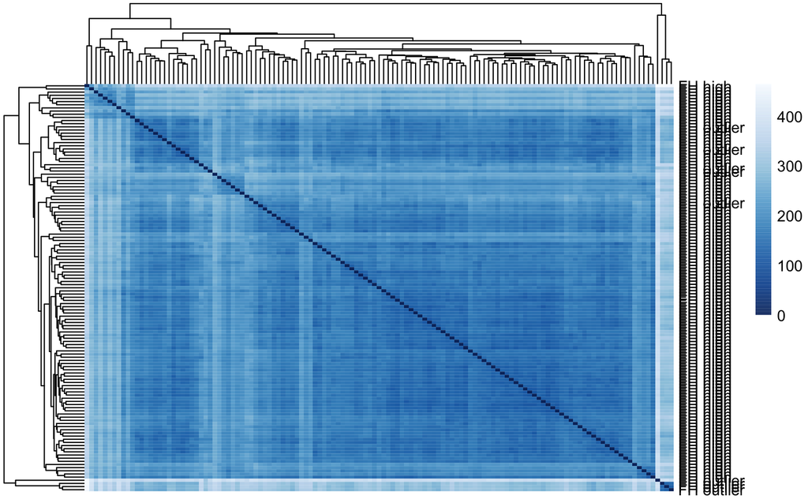

```r
library("pheatmap")
library("RColorBrewer")
label <- paste0(cancer, ': ', fhlow, ' vs ', fhcontrol)
# We calculate the euclidean distances between the samples. Note we need to transpose the matrix (t(assay(vsd))
sampleDists <- dist(t(assay(vsd)))

sampleDistMatrix <- as.matrix( sampleDists )
# Create some row names
rownames(sampleDistMatrix) <- paste( vsd$fhStatus, sep = " - " )
# Set the column names to be empty since these are just the same as the row names
colnames(sampleDistMatrix) <- NULL
colors <- colorRampPalette( rev(brewer.pal(9, "Blues")) )(255)
anno <- as.data.frame(colData(vsd)[, c("fhStatus")])

pheatmap(sampleDistMatrix,
         clustering_distance_rows = sampleDists,
         clustering_distance_cols = sampleDists,
         title=paste0("Distances between samples, ", label),
         col = colors)
```

#### PCA

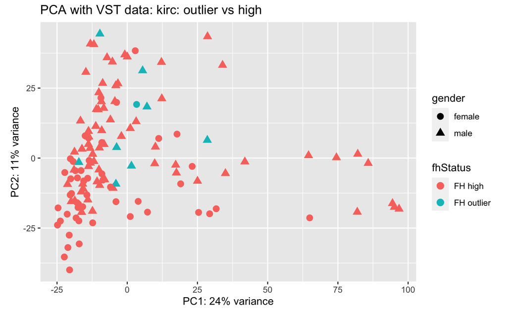

```r
pcaData <- plotPCA(vsd, intgroup = c( "fhStatus"), returnData = TRUE)
percentVar <- round(100 * attr(pcaData, "percentVar"))
ggplot(pcaData, aes(x = PC1, y = PC2, color = fhStatus, shape = gender)) +
  geom_point(size =3) +
  xlab(paste0("PC1: ", percentVar[1], "% variance")) +
  ylab(paste0("PC2: ", percentVar[2], "% variance")) +
  coord_fixed() +
  ggtitle(paste0("PCA with VST data: ", label))
```

### Running DE analysis

Now we’ll actually run the DEseq analysis using what we designed before.

#### Results columns explained

> baseMean: average of the normalized count values, divided by the size factors, taken over all samples in the DESeqDataSet log2FoldChange: effect size estimate e.g. how much a gene’s expression has changed as a result of the treatment (or in our case tumour) lfcSE: uncertainty (standard error estimate) for the log2FoldChange pvalue: the likelihood that the effect observed occured by chance (e.g. by experimetal variability etc)

Note: 1) alpha = p-value i.e. significance –> usually 0.05 (will have high FDR) 2) padj = FDR adjusted p values (by BH) –> usually 0.05 or 0.1 3) lfcThreshold = log fold change threshold –> usually 1.0

```r
# Run DEseq2
dds <- DESeq(dds)
```

```
-- replacing outliers and refitting for 2918 genes
-- DESeq argument 'minReplicatesForReplace' = 7
-- original counts are preserved in counts(dds)
```

```r
# Build results table
res <- results(dds)

# Sumarise the results
summary(res)
```

```
out of 28678 with nonzero total read count
adjusted p-value < 0.1
LFC > 0 (up)       : 11126, 39%
LFC < 0 (down)     : 4261, 15%
outliers [1]       : 0, 0%
low counts [2]     : 0, 0%
(mean count < 1)
[1] see 'cooksCutoff' argument of ?results
[2] see 'independentFiltering' argument of ?results
```

```r
# Lastly, we may want to see the results of the high logfoldchange e.g. > 1 with a padj value < 0.05
res_padj05 <- results(dds, alpha = 0.05)
res_padj05_lfcThreshold1 <- table(res_padj05$padj < 0.1)

res_padj05_lfcThreshold1
```

```
FALSE  TRUE
13291 15387
```

```r
resLFC1 <- results(dds, lfcThreshold=1)
table(resLFC1$padj < 0.1)
```

```
FALSE  TRUE
23757  4921
```

### Annotating and exporting results

```r
# Order results by p-value
resOrdered <- res[order(res$pvalue),]
outputFilename <- paste(projectDir, 'DEseq2_', cancer, '_', fhcontrol, '_', fhlow, '.csv', sep='')
write.csv(resOrdered, file = outputFilename)
```

### Visualise the significant results

Couple of plots:

```
1) Volcano plot: https://www.bioconductor.org/packages/release/bioc/vignettes/EnhancedVolcano/inst/doc/EnhancedVolcano.html
2) Heatmaps https://www.rdocumentation.org/packages/pheatmap/versions/1.0.12/topics/pheatmap :
        a) most significant genes
        b) highest logFC genes (neg and pos)
        c) most variable genes
```

```
Ignoring unknown parameters: xlim, ylim
```

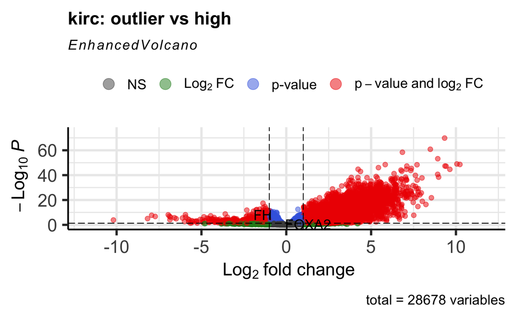

```r
#if (!requireNamespace('BiocManager', quietly = TRUE))
#    install.packages('BiocManager')

#BiocManager::install('EnhancedVolcano')
library(EnhancedVolcano)
# Let's make a volcano plot
EnhancedVolcano(res,
  lab = rownames(res),
  x = 'log2FoldChange',
  y = 'padj',
  pCutoff=0.05,
  selectLab=c('FH', 'FOXA2'),
  title = label)
```

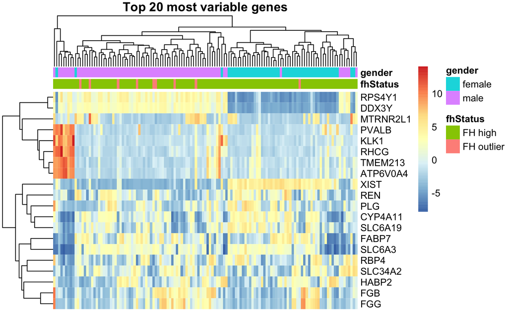

```r
# Top genes as per variance
topVarGenes <- head(order(rowVars(assay(vsd)), decreasing = TRUE), 20)
res$symbol <- rownames(res)
mat  <- assay(vsd)[ topVarGenes, ]
rownames(mat) <- res$symbol[topVarGenes]
mat  <- mat - rowMeans(mat)
anno <- as.data.frame(colData(vsd)[, c("fhStatus", "gender")])  # ,"gender", "tumourStage"
pheatmap(mat, annotation_col = anno, show_colnames = F, main="Top 20 most variable genes")
```

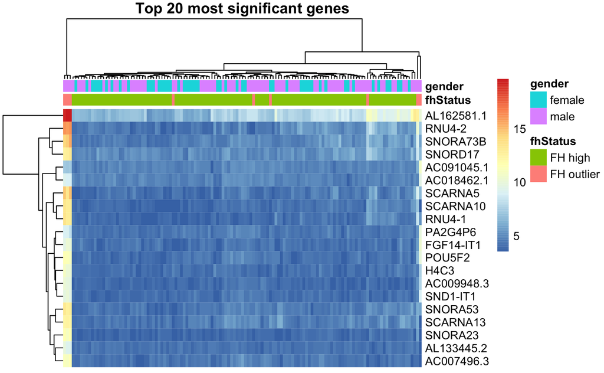

```r
# Top genes as per significance
topSig <- head(order(res$padj, decreasing = FALSE), 20)
ids <- rownames(res[topSig,])
mat  <- assay(vsd[ids])
rownames(mat) <- res$symbol[topSig]
anno <- as.data.frame(colData(vsd)[, c("fhStatus", "gender")]) # ,"gender", "tumourStage"
pheatmap(mat, annotation_col = anno, show_colnames = F, main="Top 20 most significant genes")
```